# Exercise 7: Maximising plant productivity

# Instructions:

This document contains information, questions, R code, and plots.

**Hints and reminders are bold**

Questions appear in blue.

**Needs to be completed and handed in by 19th March 23:59**

# Resources:

- More details on the data p84 The New Statistics with R
- Chapters 6 and 7 in The New Statistics with R (both examples in these chapters)

## R this week:

Things to remember:

- `lm()` with interactions. Use `*`.
- `relevel()` a function to change the reference level of a categorical variable/factor. This controls which group in the categorical variable will appear as the (Intercept).

# The challenge: How can we maximise plant productivity?

You are a team of agricultural scientists working for a large farming company. The company has employed you to find out how they can increase the productivity of their arable (plants) crops. The company don’t want to pay for new experiments but they have given you some older data that you can analyse. The older data is from two different experiments from 2009 and 1990.

Your job is to find out how different management practices influence plant growth and recommend a plan for the company.

# Part A: Dataset one - no interaction

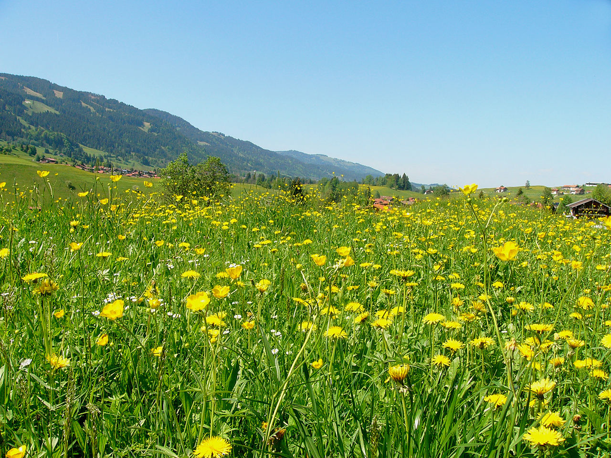

Meadow

- credit Wikipedia

The first dataset the company has given you can be found at https://www.math.ntnu.no/emner/ST2304/2019v/Week9/FertilizerData.csv

The data were published in 2009 by Hautier, Niklaus, and Hector [Paper link](http://science.sciencemag.org/content/324/5927/636.long). The study was designed to look at the influence of fertiliser and light on grassland plants. 32 different plots were exposed to fertiliser addition, a light addition to the understory, neither (control), or both treatments. The treatments were conducted for two years and above ground biomass collected twice a year to mimic cutting regimes in European meadows.

The dataset includes the variables; **Biomass.m2** the above ground biomass of grassland plants in grams per metre squared, **Fert** a column indicating if the plots had fertiliser treatment, **Light** a column indicating if the plots had light addition.

As always, the first step is to import the data and assign it to an object then **plot it**. You can use the whole web link above to import the data. It is a csv file with column names (header) included.

**`pairs()` should work here.**

You might also want to relevel the factors (Fert and Light) to make sure that the contrast level will be the control treatment (light and fertiliser = FALSE).

To do this you use the function `relevel()`. The arguments it takes are the column name of the factor/categorical variable that you want to relevel and `ref=` the level that you want to be the reference e.g. `FertData$Light <- relevel(FertData$Light, ref="L-")`.

**You will also need to turn BOTH Light and Fert into factors using `as.factor()`**. This was done in the module from week 9.

Take a look at the plot and think about the data

A1. **What** is the response variable and **what** are the explanatory variables here? **What** kind of data are each of these?

In biology, it is always important to think about what we want to find out before creating a model or doing analyses.

A2. **Write** a biological question (e.g. does temperature influence lay date in birds?) that you can answer using the data you have here.

Now that you have a biological question, your team wants to create a model of the data. You can do this using `lm()`. It is important to remember that this time there are two explanatory variables, so both need to be included in the model. For now we will include them without an interaction.

A3. **Run** the `lm()` to look at the impact of fertiliser and light on above ground biomass. **What** are the coefficient estimates you get? **What** do they represent?

A4. **Interpret** the results in qu A3. **What** conclusions would you draw about the effectiveness of Fertiliser and Light from these results?

Given the results from your `lm()` above, it was not possible to see the combined effect of the two treatments (Fertiliser and Light). However, there was a treatment where they were both applied together so we should consider their combined effect.

A5. **How** can you use your model output to estimate the mean of the group that has fertiliser and light?

**Hint.**

In the output you have an estimate for the effect of fertiliser (difference in mean from control to fertiliser group). You also have an estimate of the effect of light (difference in mean from control to light group). In this model there is no interaction, so you assume that the fertiliser + light group has the same effects as the fertiliser only and light only, but, both of them.

A6. Calculate the actual mean of the fertiliser + light group. Is the estimate you got in A5 correct? If not, why not?

**How do I get the mean?**

You can use the same code as in the module this week. Hint: it uses `[]` and `==`.

**No, I don’t remember**

```r
# take mean of the group F+ and L+
mean(FertData$Biomass.m2[FertData$Fert == "F+" & FertData$Light == "L+"])
```

```
## [1] 575.0187
```

A7. Can you give a biological reason why this might be the case? i.e. why does the actual mean differ from our model estimate?

Your team has looked at the results above and decided that the first model they fitted is not capturing the effects of Fertiliser and Light well enough. There seems to be something else going on when the two treatments are combined. The two effects are not simply added together. Therefore, your team decides to fit a model including an interaction term.